# Analiza porównawcza cech morfologicznych kwiatów z wykorzystaniem zbioru danych Iris

Lidia Furgał

Politechnika Krakowska

Wczytajmy wbudowany zbiór danych *iris* w środowisku R, a następnie wyświetlmy jego zawartość, aby zaprezentować strukturę i pierwsze obserwacje danych.

```r
flowers <- as_tibble(iris)
flowers
```

| Sepal.Length | Sepal.Width | Petal.Length | Petal.Width | Species |
| --- | --- | --- | --- | --- |
| 5.1 | 3.5 | 1.4 | 0.2 | setosa |
| 4.9 | 3.0 | 1.4 | 0.2 | setosa |
| 4.7 | 3.2 | 1.3 | 0.2 | setosa |
| 4.6 | 3.1 | 1.5 | 0.2 | setosa |
| 5.0 | 3.6 | 1.4 | 0.2 | setosa |
| 5.4 | 3.9 | 1.7 | 0.4 | setosa |
| 4.6 | 3.4 | 1.4 | 0.3 | setosa |
| 5.0 | 3.4 | 1.5 | 0.2 | setosa |
| 4.4 | 2.9 | 1.4 | 0.2 | setosa |
| 4.9 | 3.1 | 1.5 | 0.1 | setosa |

[output cut: 140 more lines]

W podanej powyżej tabeli danych przedstawiono wartości długości i szerokości działek kielicha (ang. *sepal length* oraz *sepal width*) wraz z długością i szerokością płatków (ang. *petal length* oraz *petal width*) dla trzech gatunków roślin: *Setosa*, *Versicolor* i *Virginica*.

Aby ułatwić przegląd danych, podzielmy tabelę *iris* względem gatunków roślin.

```r
colnames(flowers) <- c("Działki_Kielicha_Długość", "Działki_Kielicha_Szerokość","Długość_Płatka", "Szerokość_Płatka","Gatunek")
```

```r
data_split <- split(flowers,flowers$Gatunek)
```

```r
setosa <- filter(flowers, Gatunek == "setosa")
setosa
```

| Działki_Kielicha_Długość | Działki_Kielicha_Szerokość | Długość_Płatka | Szerokość_Płatka | Gatunek |
| --- | --- | --- | --- | --- |
| 5.1 | 3.5 | 1.4 | 0.2 | setosa |
| 4.9 | 3.0 | 1.4 | 0.2 | setosa |
| 4.7 | 3.2 | 1.3 | 0.2 | setosa |
| 4.6 | 3.1 | 1.5 | 0.2 | setosa |
| 5.0 | 3.6 | 1.4 | 0.2 | setosa |
| 5.4 | 3.9 | 1.7 | 0.4 | setosa |
| 4.6 | 3.4 | 1.4 | 0.3 | setosa |
| 5.0 | 3.4 | 1.5 | 0.2 | setosa |
| 4.4 | 2.9 | 1.4 | 0.2 | setosa |
| 4.9 | 3.1 | 1.5 | 0.1 | setosa |

[output cut: 40 more lines]

```r
versicolor<- filter(flowers, Gatunek == "versicolor")
versicolor
```

| Działki_Kielicha_Długość | Działki_Kielicha_Szerokość | Długość_Płatka | Szerokość_Płatka | Gatunek |
| --- | --- | --- | --- | --- |
| 7.0 | 3.2 | 4.7 | 1.4 | versicolor |
| 6.4 | 3.2 | 4.5 | 1.5 | versicolor |
| 6.9 | 3.1 | 4.9 | 1.5 | versicolor |
| 5.5 | 2.3 | 4.0 | 1.3 | versicolor |
| 6.5 | 2.8 | 4.6 | 1.5 | versicolor |
| 5.7 | 2.8 | 4.5 | 1.3 | versicolor |
| 6.3 | 3.3 | 4.7 | 1.6 | versicolor |
| 4.9 | 2.4 | 3.3 | 1.0 | versicolor |
| 6.6 | 2.9 | 4.6 | 1.3 | versicolor |
| 5.2 | 2.7 | 3.9 | 1.4 | versicolor |

[output cut: 40 more lines]

```r
virginica <- filter(flowers, Gatunek == "virginica")
virginica
```

| Działki_Kielicha_Długość | Działki_Kielicha_Szerokość | Długość_Płatka | Szerokość_Płatka | Gatunek |
| --- | --- | --- | --- | --- |
| 6.3 | 3.3 | 6.0 | 2.5 | virginica |
| 5.8 | 2.7 | 5.1 | 1.9 | virginica |
| 7.1 | 3.0 | 5.9 | 2.1 | virginica |
| 6.3 | 2.9 | 5.6 | 1.8 | virginica |
| 6.5 | 3.0 | 5.8 | 2.2 | virginica |
| 7.6 | 3.0 | 6.6 | 2.1 | virginica |
| 4.9 | 2.5 | 4.5 | 1.7 | virginica |
| 7.3 | 2.9 | 6.3 | 1.8 | virginica |
| 6.7 | 2.5 | 5.8 | 1.8 | virginica |
| 7.2 | 3.6 | 6.1 | 2.5 | virginica |

[output cut: 40 more lines]

Aby zwizualizować dane dla poszczególnych gatunków kwiatów, wykorzystajmy wykres pudełkowy (*boxplot*).

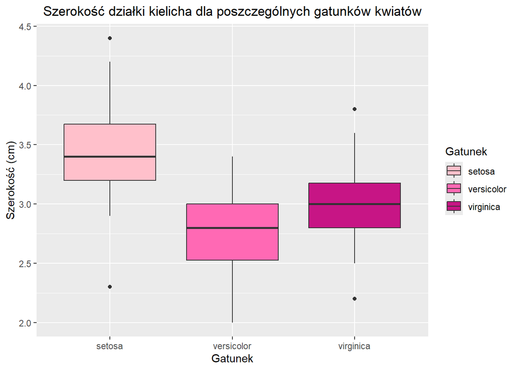

```r
ggplot(data=flowers, aes(x=Gatunek, y= Działki_Kielicha_Szerokość,fill = Gatunek)) + geom_boxplot()+ scale_fill_manual(values=c("#FFC0CB", "#FF69B4", "#C71585")) + ggtitle("Szerokość działki kielicha dla poszczególnych gatunków kwiatów") +
  theme(plot.title = element_text(hjust = 0.5)) + xlab("Gatunek") + ylab("Szerokość (cm)")
```

Powyższy wykres pudełkowy dostarcza informacji na temat mediany, minimalnej oraz maksymalnej wartości szerokości działek kielicha dla poszczególnych gatunków kwiatów. Mediana szerokości działek kielicha dla każdego gatunku jest reprezentowana przez poziomą czarną kreskę znajdującą się w obrębie pudełka. Wykres ten umożliwia łatwe porównanie rozkładu szerokości działek kielicha między różnymi gatunkami oraz identyfikację ewentualnych wartości odstających.

#### Mediana szerokości działek kielicha

- Gatunek *Setosa* przyjmuje wartość szerokości działek kielicha w przedziale od 3,25 do 3,5 cm,
- Gatunek *Versicolor* ma szerokość działek kielicha w przedziale od 2,25 do 3 cm.
- Gatunek *Virginica* przyjmuje dokładnie 3 cm.

Najmniejsze i największe wartości szerokości działek kielicha są przedstawione na końcach, tzw. wąsach wykresu pudełkowego.

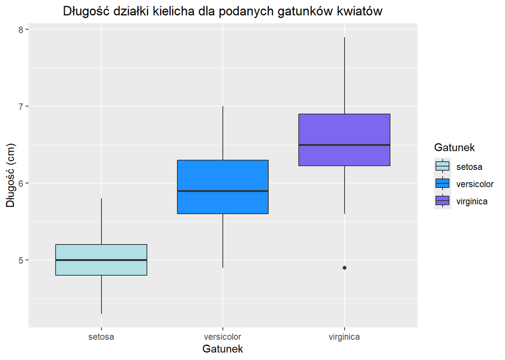

```r
ggplot(data=flowers, aes(x=Gatunek, y= Działki_Kielicha_Długość,fill = Gatunek)) + geom_boxplot()+ scale_fill_manual(values=c("#B0E0E6", "#1E90FF", "#7B68EE")) + ggtitle("Długość działki kielicha dla podanych gatunków kwiatów") +
  theme(plot.title = element_text(hjust = 0.5)) + xlab("Gatunek") + ylab("Długość (cm)")
```

#### Mediana długości działek kielicha

- Gatunek *Setosa*: Mediana długości działek kielicha wynosi 5 cm.
- Gatunek *Versicolor*: Mediana długości działek kielicha mieści się w przedziale od 5,5 do 6 cm.
- Gatunek *Virginica*: Mediana długości działek kielicha wynosi dokładnie 6,5 cm.

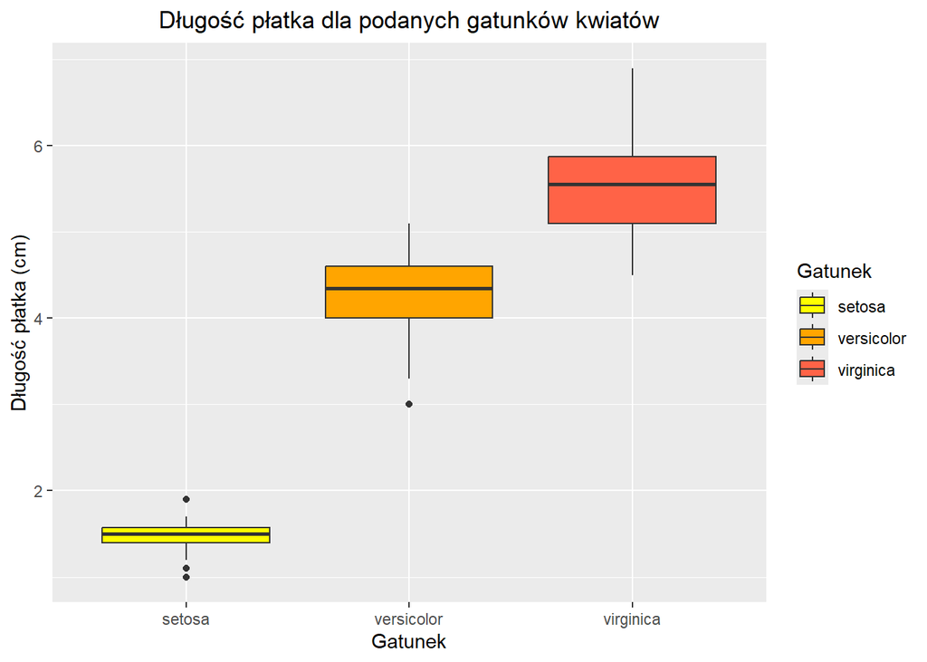

```r
ggplot(data=flowers, aes(x=Gatunek, y= Długość_Płatka,fill = Gatunek)) + geom_boxplot()+ scale_fill_manual(values=c("#FFFF00", "#FFA500", "#FF6347")) + ggtitle("Długość płatka dla podanych gatunków kwiatów") +
  theme(plot.title = element_text(hjust = 0.5)) + xlab("Gatunek") + ylab("Długość płatka (cm)")
```

#### Mediana długości płatka

- Gatunek *Setosa*: Mediana długości płatka wynosi od 1 do 2 cm.
- Gatunek *Versicolor*: Mediana długości płatka mieści się w przedziale od 4 do 5 cm.
- Gatunek *Virginica*: Mediana długości płatka wynosi od 5 do 6 cm.

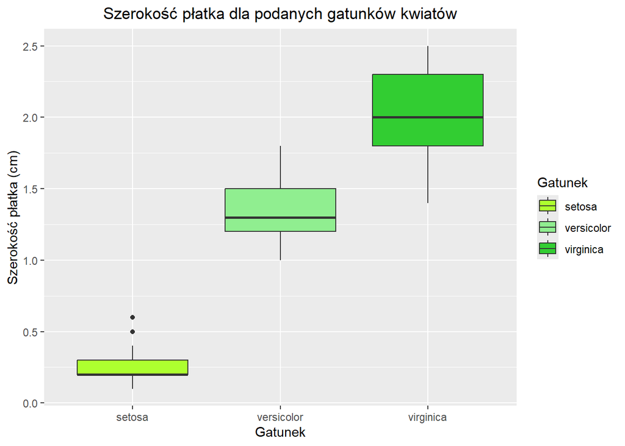

```r
ggplot(data=flowers, aes(x=Gatunek, y=Szerokość_Płatka,fill = Gatunek)) + geom_boxplot()+ scale_fill_manual(values=c("#ADFF2F", "#90EE90", "#32CD32")) + ggtitle("Szerokość płatka dla podanych gatunków kwiatów") + theme(plot.title = element_text(hjust = 0.5)) + xlab("Gatunek") + ylab("Szerokość płatka (cm)")
```

Na poniższych wykresach kropkowych porównamy zależności między cechami różnych gatunków, co pozwoli na lepszą wizualizację różnic i podobieństw w szerokości płatków.

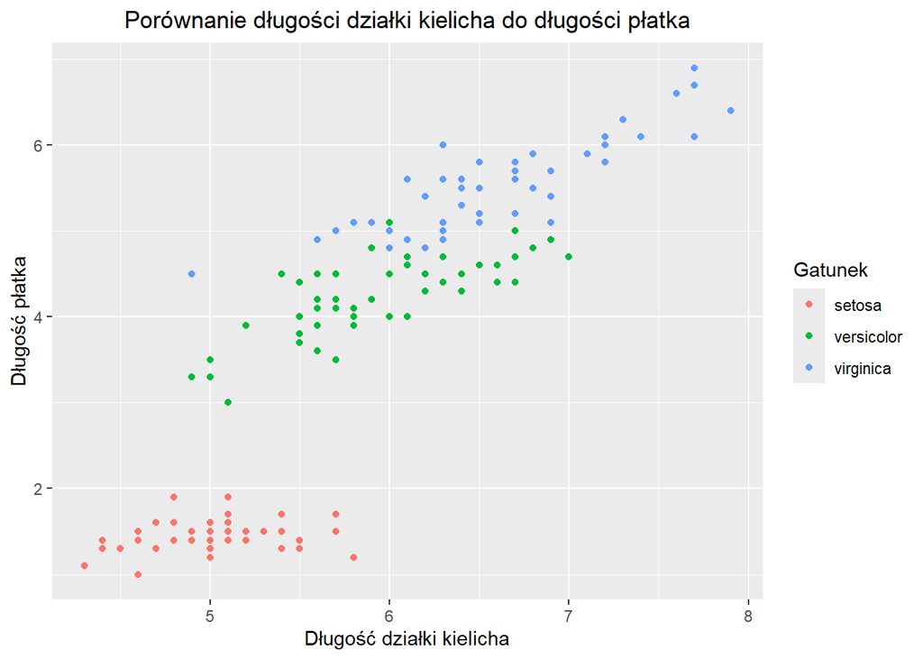

```r
ggplot(data=flowers, aes(x=Działki_Kielicha_Długość, y=Długość_Płatka, color=Gatunek))  + geom_point()+ggtitle("Porównanie długości działki kielicha do długości płatka") +
  theme(plot.title = element_text(hjust = 0.5)) + ylab('Długość płatka') + xlab('Długość działki kielicha')
```

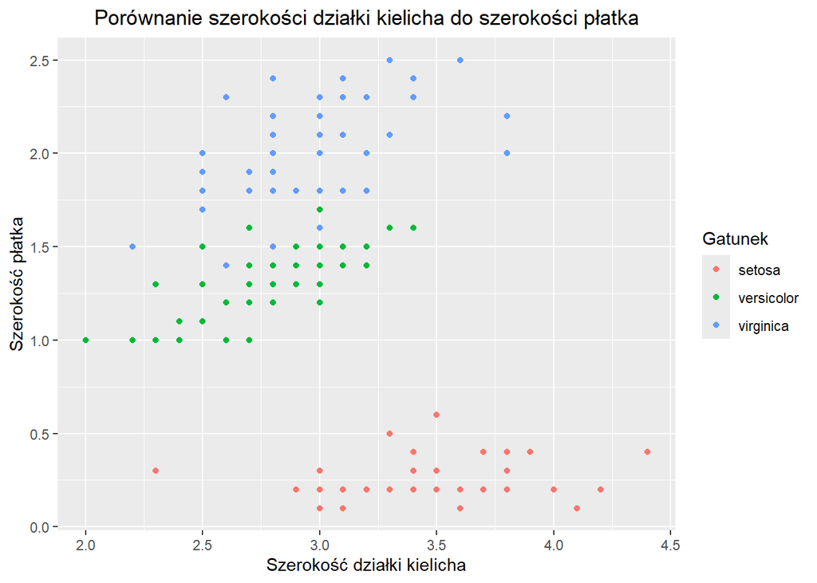

```r
ggplot(data=flowers, aes(x=Działki_Kielicha_Szerokość, y=Szerokość_Płatka, color=Gatunek)) + geom_point() + ggtitle("Porównanie szerokości działki kielicha do szerokości płatka") +
  theme(plot.title = element_text(hjust = 0.5))+ylab('Szerokość płatka') + xlab('Szerokość działki kielicha')
```

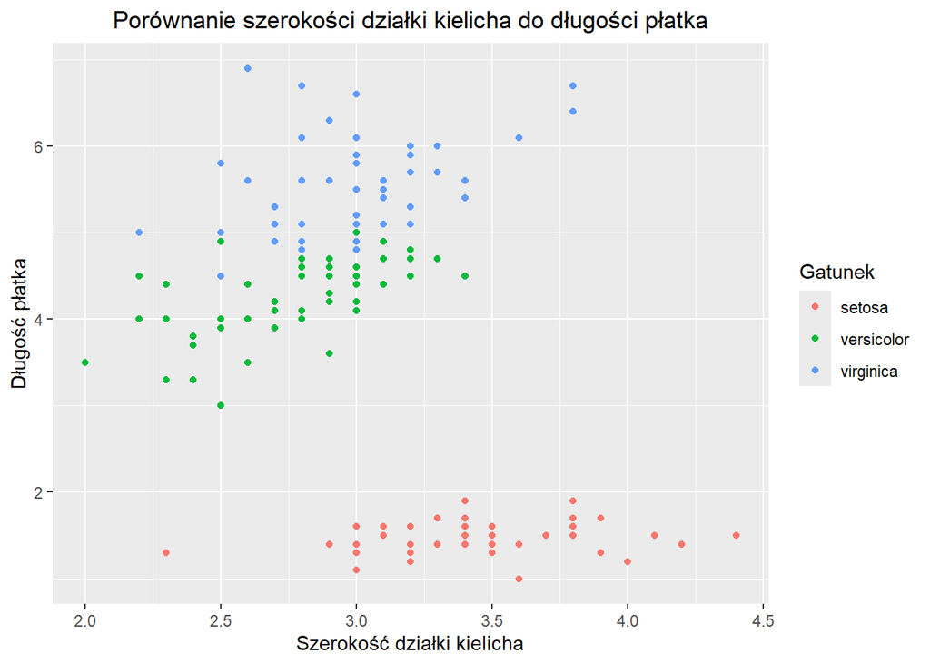

```r
ggplot(data=flowers, aes(x=Działki_Kielicha_Szerokość, y=Długość_Płatka, color=Gatunek)) + geom_point() + ggtitle("Porównanie szerokości działki kielicha do długości płatka") +
  theme(plot.title = element_text(hjust = 0.5))+ylab('Długość płatka') + xlab('Szerokość działki kielicha')
```

Aby uzyskać informacje na temat długości i szerokości działek kielicha oraz płatków dla różnych gatunków kwiatów, możemy wykorzystać histogramy.

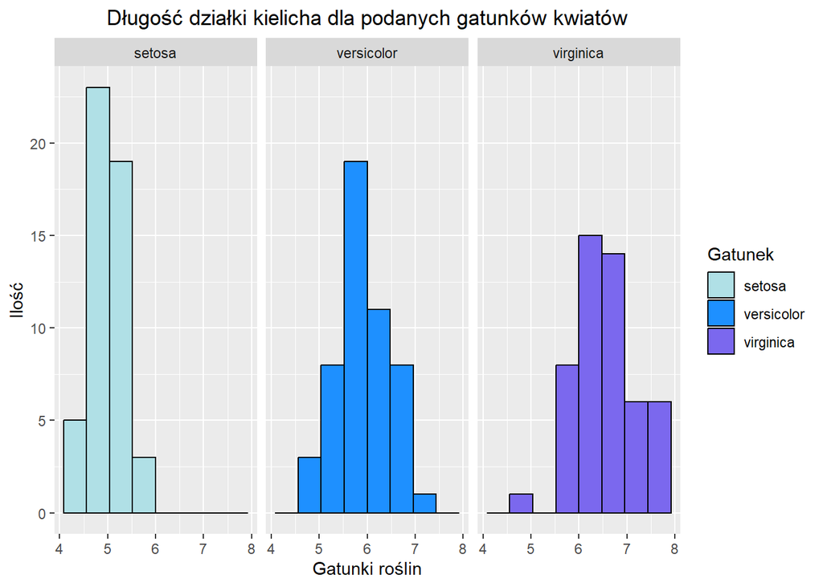

```r
ggplot(data = flowers , aes(x=Działki_Kielicha_Długość,fill=Gatunek)) + geom_histogram(bins = 17,binwidth = 0.48,color='black') + facet_wrap(~Gatunek)+scale_fill_manual(values=c("#B0E0E6", "#1E90FF", "#7B68EE")) + ggtitle("Długość działki kielicha dla podanych gatunków kwiatów") +
  theme(plot.title = element_text(hjust = 0.5)) + xlab("Gatunki roślin") + ylab("Ilość")
```

Patrząc na histogramy, możemy zauważyć następujące trendy dla długości działek kielicha w poszczególnych gatunkach:

- Dla gatunku *Setosa*: Najwięcej obserwacji skupia się w przedziale długości działek kielicha od 4,5 do 5 cm. Jest to przedział z największą liczbą populacji dla tego gatunku.
- Dla gatunku *Versicolor*: Największa liczba obserwacji występuje w przedziale od 5,5 do 6 cm.
- Dla gatunku *Virginica*: Najwięcej danych koncentruje się w przedziale długości działek kielicha od 6 do 6,5 cm.

W kontekście długości działek kielicha, najmniejsze wartości są charakterystyczne dla gatunku *Setosa*, podczas gdy największe wartości występują u gatunku *Virginica*.

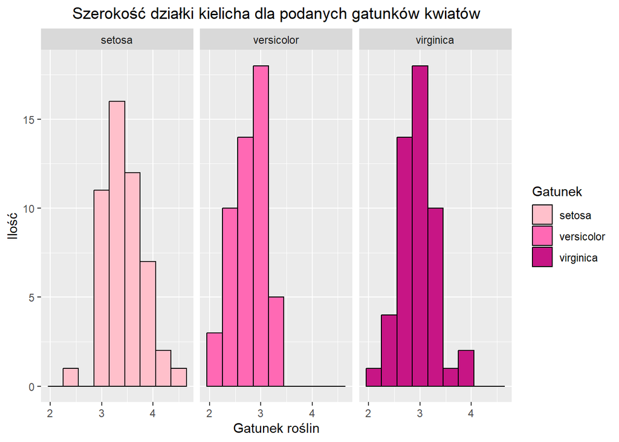

```r
ggplot(data = flowers , aes(x=Działki_Kielicha_Szerokość,fill=Gatunek)) + geom_histogram(bins = 17,binwidth = 0.3,color='black') + facet_wrap(~Gatunek)+ scale_fill_manual(values=c("#FFC0CB", "#FF69B4", "#C71585")) + ggtitle("Szerokość działki kielicha dla podanych gatunków kwiatów") +
  theme(plot.title = element_text(hjust = 0.5)) + xlab("Gatunek roślin") + ylab("Ilość")
```

Szerokość działek kielicha w poszczególnych gatunkach prezentuje się następująco:

- Dla gatunku *Setosa*: Największa liczba obserwacji skupia się w przedziale szerokości działek kielicha od 3 do 3,5 cm. Jest to przedział z największą liczbą populacji dla tego gatunku.
- Dla gatunku *Versicolor*: Najwięcej danych występuje w przedziale szerokości działek kielicha od około 2,8 do 3,1 cm.
- Dla gatunku *Virginica*: Rozkład szerokości działek kielicha jest zbliżony do rozkładu dla gatunku *Versicolor*, z wartościami mieszczącymi się w podobnych przedziałach.

W kontekście szerokości działek kielicha, największe wartości są charakterystyczne dla gatunku *Setosa*, podczas gdy najmniejsze wartości są typowe dla gatunku *Versicolor*.

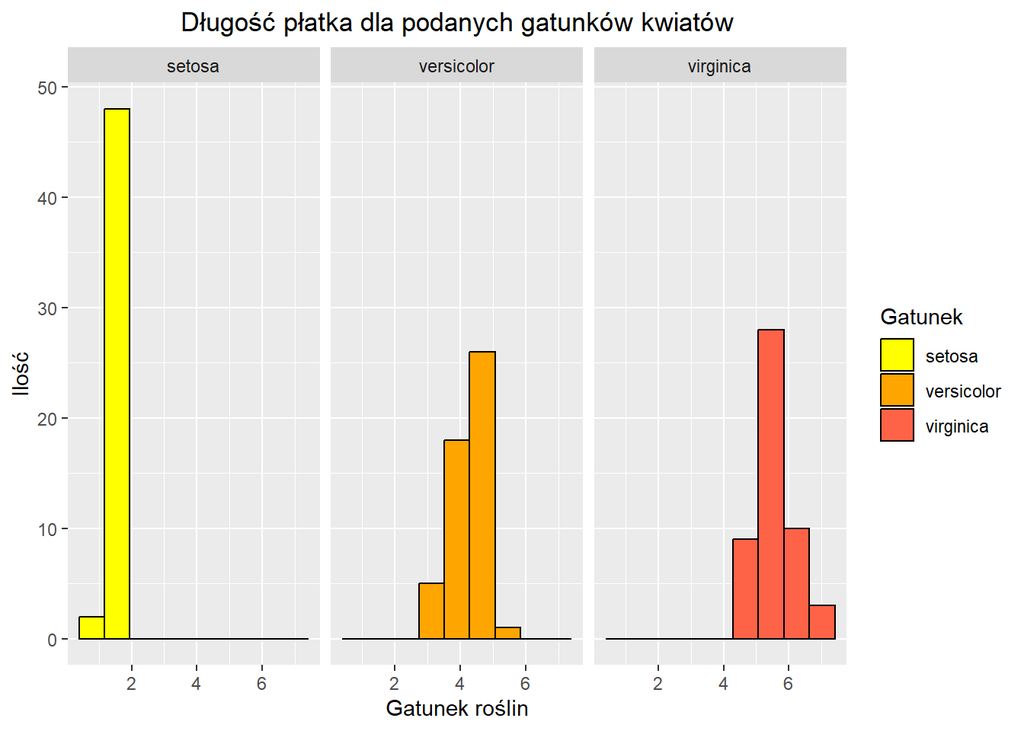

```r
ggplot(data = flowers , aes(x=Długość_Płatka,fill=Gatunek)) + geom_histogram(bins = 17,binwidth = 0.78,color='black') + facet_wrap(~Gatunek)+
  scale_fill_manual(values=c("#FFFF00", "#FFA500", "#FF6347")) + ggtitle("Długość płatka dla podanych gatunków kwiatów") +
  theme(plot.title = element_text(hjust = 0.5)) + xlab("Gatunek roślin") + ylab("Ilość")
```

Długość płatków w poszczególnych gatunkach prezentuje się następująco:

- Dla gatunku *Setosa*: Największa liczba obserwacji koncentruje się w przedziale od 1,5 do 2 cm, co wskazuje na największą populację w tym zakresie długości dla tego gatunku.
- Dla gatunku *Versicolor*: Najwięcej danych występuje w przedziale od około 4,2 do 5,1 cm.
- Dla gatunku *Virginica*: Długość płatków dla tego gatunku jest największa, mieszcząc się w przedziale od około 5 do 6 cm.

Podsumowując, największe wartości długości płatków są charakterystyczne dla gatunku *Virginica*, podczas gdy najmniejsze wartości występują u gatunku *Setosa*.

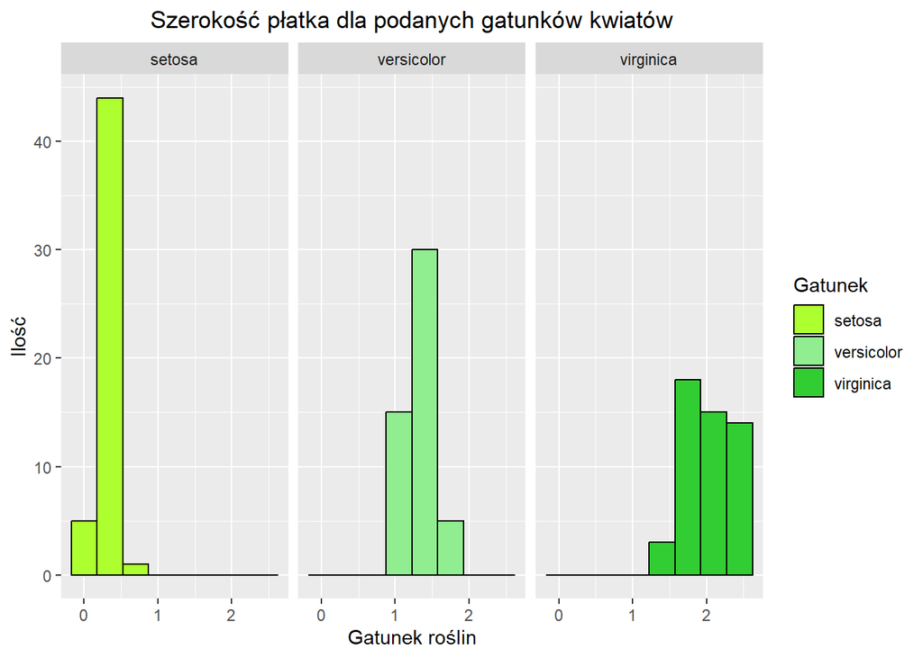

```r
ggplot(data = flowers , aes(x=Szerokość_Płatka,fill=Gatunek)) + geom_histogram(bins = 15,binwidth = 0.35,color='black') +scale_fill_manual(values=c("#ADFF2F", "#90EE90", "#32CD32")) + ggtitle("Szerokość płatka dla podanych gatunków kwiatów") + theme(plot.title = element_text(hjust = 0.5)) + xlab("Gatunek roślin") + ylab("Ilość")+ facet_wrap(~Gatunek)
```

Podsumowując, największe wartości szerokości płatków są charakterystyczne dla gatunku *Virginica*, podczas gdy najmniejsze wartości występują u gatunku *Setosa*.

# Test Parametryczny

Aby sprawdzić, czy szerokość działek kielicha ma wpływ na długość płatków dla poszczególnych gatunków kwiatów, możemy przeprowadzić test korelacji i zweryfikować istotność współczynnika korelacji. Użyjemy testu korelacji Pearsona oraz sprawdzimy istotność statystyczną współczynnika korelacji na poziomie istotności $\alpha = 0,05$.

W związku z analizą wpływu szerokości działek kielicha na długość płatków, przyjmujemy następujące hipotezy: ${H_0}:\delta=0$ - szerokość działek kielicha nie ma wpływ na długość płatka, i alternatywną ${H_1}:\delta\neq0$ - szerokość działek kielicha ma wpływ na długość płatka.

```r
cor.test(setosa$Działki_Kielicha_Szerokość,setosa$Długość_Płatka)
```

```
##
##  Pearson's product-moment correlation
##
## data:  setosa$Działki_Kielicha_Szerokość and setosa$Długość_Płatka
## t = 1.2511, df = 48, p-value = 0.217
## alternative hypothesis: true correlation is not equal to 0
## 95 percent confidence interval:
##  -0.1058851  0.4345536
## sample estimates:
##    cor
## 0.1777
```

Jako że wartość $p = 0,217$, czyli jest wyższa od przyjętego poziomu istotności wynoszącego $\alpha =0.05$, to w tym wypadku nie możemy odrzucić hipotezy zerowej mówiązej nam, że szerokość działek kielicha dla *Setosa* nie ma wpływu na długość płatka. Dodatkowo na podstawie współczynika korelacji możemy stwierdzić, że istnieje słaba zależność między rozważanymi zmiennymi.

```r
cor.test(virginica$Działki_Kielicha_Szerokość,virginica$Długość_Płatka)
```

```
##
##  Pearson's product-moment correlation
##
## data:  virginica$Działki_Kielicha_Szerokość and virginica$Długość_Płatka
## t = 3.0331, df = 48, p-value = 0.003898
## alternative hypothesis: true correlation is not equal to 0
## 95 percent confidence interval:
##  0.1381146 0.6111677
## sample estimates:
##       cor
## 0.4010446
```

Wartość $p = 0,003898$, czyli jest niższa od przyjętego poziomu istotności $\alpha =0,05$, to odrzucamy hipotezę zerową. W tym wypadku możemy założyć, że szerokość działek kielicha dla *Virginica* ma wpływu na długość płatka. Dodatkowo, na podstawie współczynnika korelacji możemy zauważyć, że istnieje jedynie słaba zależność między szerokością działek kielicha a długością płatków dla tego gatunku. W związku z tym, wpływ szerokości działek kielicha na długość płatków jest nieznaczny i nieistotny statystycznie w przypadku gatunku *Setosa*.

```r
cor.test(versicolor$Działki_Kielicha_Szerokość,versicolor$Długość_Płatka)
```

```
##
##  Pearson's product-moment correlation
##
## data:  versicolor$Działki_Kielicha_Szerokość and versicolor$Długość_Płatka
## t = 4.6893, df = 48, p-value = 2.302e-05
## alternative hypothesis: true correlation is not equal to 0
## 95 percent confidence interval:
##  0.3343378 0.7256533
## sample estimates:
##       cor
## 0.5605221
```

Wartość $p = 2,302\cdot10^{-5}$ jest znacznie niższa od przyjętego poziomu istotności $\alpha =0,05$. W związku z tym odrzucamy hipotezę zerową i przyjmujemy hipotezę alternatywną, co sugeruje, że szerokość działek kielicha dla gatunku *Versicolor* ma istotny wpływ na długość płatków.

Dodatkowo, na podstawie współczynnika korelacji możemy stwierdzić, że istnieje silna zależność między szerokością działek kielicha a długością płatków. Oznacza to, że im większa szerokość działek kielicha, tym dłuższe są płatki w przypadku gatunku *Versicolor*.

Podsumowując, największa zależność między szerokością działek kielicha a długością płatków występuje dla gatunku *Versicolor*. W przypadku tego gatunku stwierdzono silny wpływ szerokości działek kielicha na długość płatków. Z kolei najsłabsza zależność obserwowana jest dla gatunku *Setosa*, gdzie wpływ szerokości działek kielicha na długość płatków jest minimalny i nieistotny statystycznie.

# Test Permutacyjny

```r
n <-50000
corelation<-rep(0,n)
for (i in 1:n) {
  sample_1<-sample(versicolor$Szerokość_Płatka,50,replace = FALSE)
  corelation[i] <- cor(versicolor$Długość_Płatka,sample_1)
}
quantile(corelation,c(0.025,0.975))
```

```
##       2.5%      97.5%
## -0.2762782  0.2793528
```

```r
n <-50000
corelation<-rep(0,n)
for (i in 1:n) {
  sample_2<-sample(setosa$Szerokość_Płatka,50,replace = FALSE)
  corelation[i] <- cor(setosa$Długość_Płatka,sample_2)
}
quantile(corelation,c(0.025,0.975))
```

```
##       2.5%      97.5%
## -0.2816737  0.2870261
```

```r
n <-50000
corelation<-rep(0,n)
for (i in 1:n) {
  sample_3<-sample(virginica$Szerokość_Płatka,50,replace = FALSE)
  corelation[i] <- cor(virginica$Długość_Płatka,sample_3)
}
quantile(corelation,c(0.025,0.975))
```

```
##       2.5%      97.5%
## -0.2770314  0.2776776
```